# BLSA Biomarker Analysis

## TOTAL T4 (ug/dL = mcg/dL)

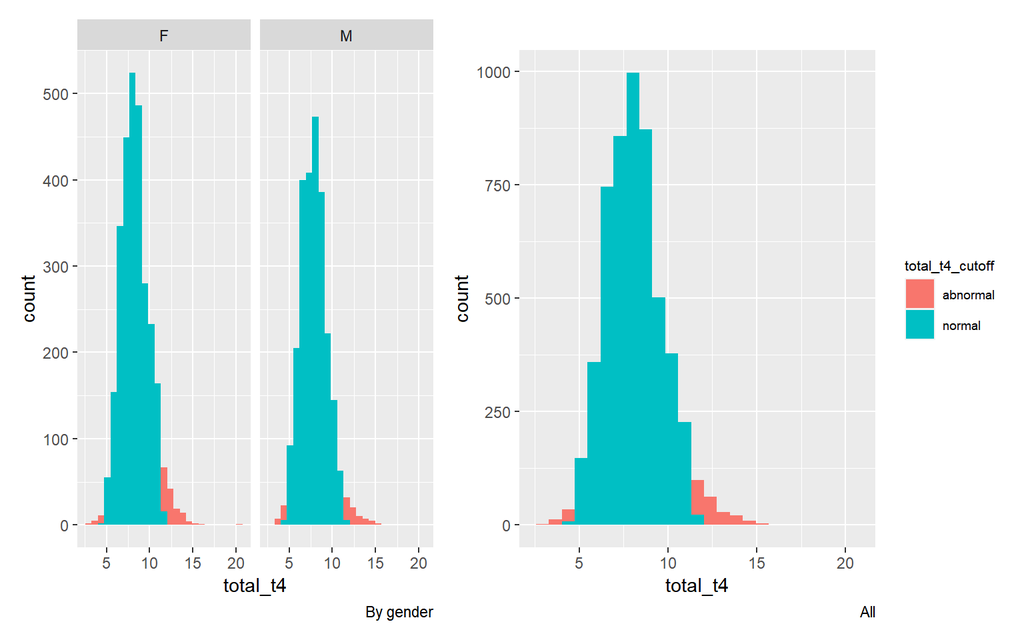

```r
total_t4_gender_plot =
  new_blsa_clean %>%
  ggplot() +
  geom_histogram(aes(x = total_t4, fill = total_t4_cutoff), bins = 25) +
  facet_wrap(~gender) +
  theme(legend.position = "none") +
  labs(caption = "By gender") +
  scale_fill_discrete(breaks = c("abnormal", "normal"))

total_t4_all_plot =
  new_blsa_clean %>%
  ggplot() +
  geom_histogram(aes(x = total_t4, fill = total_t4_cutoff), bins = 25) +
  theme(legend.text = element_text(size = 7),
        legend.title = element_text(size = 8)) +
  labs(caption = "All") +
  scale_fill_discrete(breaks = c("abnormal", "normal"))

total_t4_fig = total_t4_gender_plot + total_t4_all_plot
total_t4_fig
```

## Total Testosterone (ng/dL)

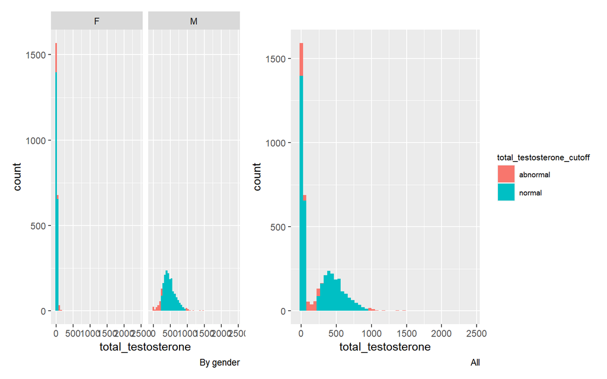

```r
total_testosterone_gender_plot =
  new_blsa_clean %>%
  ggplot() +
  geom_histogram(aes(x = total_testosterone, fill = total_testosterone_cutoff), bins = 50) +
  facet_wrap(~gender) +
  theme(legend.position = "none") +
  labs(caption = "By gender") +
  scale_fill_discrete(breaks = c("abnormal", "normal"))

total_testosterone_all_plot =
  new_blsa_clean %>%
  ggplot() +
  geom_histogram(aes(x = total_testosterone, fill = total_testosterone_cutoff), bins = 50) +
  theme(legend.text = element_text(size = 7),
        legend.title = element_text(size = 8)) +
  labs(caption = "All") +
  scale_fill_discrete(breaks = c("abnormal", "normal"))

total_testosterone_fig = total_testosterone_gender_plot + total_testosterone_all_plot
total_testosterone_fig
```

## Triglycerides (mg/dL)

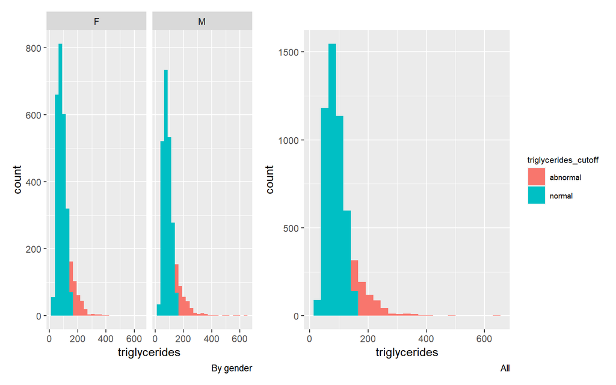

```r
triglycerides_gender_plot =
  new_blsa_clean %>%
  ggplot() +
  geom_histogram(aes(x = triglycerides, fill = triglycerides_cutoff), bins = 25) +
  facet_wrap(~gender) +
  theme(legend.position = "none") +
  labs(caption = "By gender") +
  scale_fill_discrete(breaks = c("abnormal", "normal"))

triglycerides_all_plot =
  new_blsa_clean %>%
  ggplot() +
  geom_histogram(aes(x = triglycerides, fill = triglycerides_cutoff), bins = 25) +
  theme(legend.text = element_text(size = 7),
        legend.title = element_text(size = 8)) +
  labs(caption = "All") +
  scale_fill_discrete(breaks = c("abnormal", "normal"))

triglycerides_fig = triglycerides_gender_plot + triglycerides_all_plot
triglycerides_fig
```

## TSH (mIU/L)

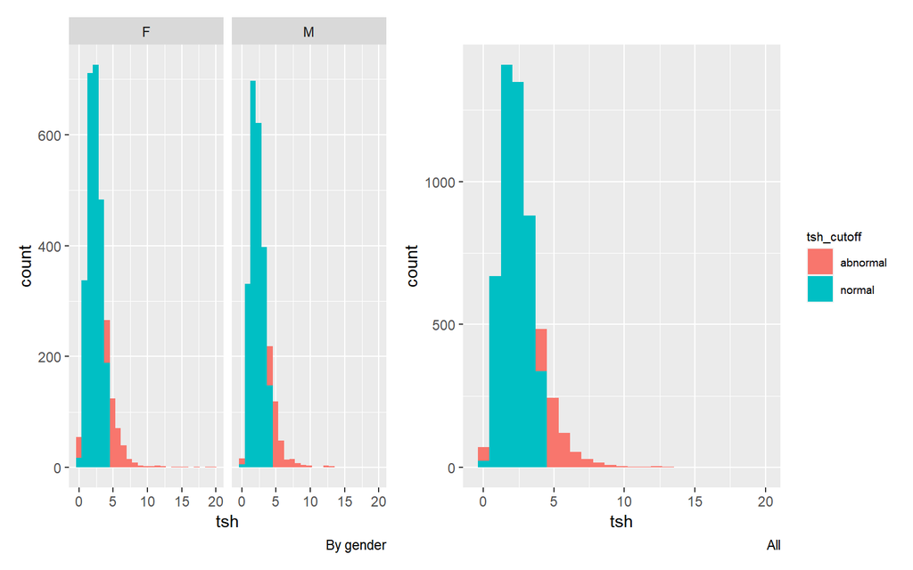

```r
tsh_gender_plot =
  new_blsa_clean %>%
  ggplot() +
  geom_histogram(aes(x = tsh, fill = tsh_cutoff), bins = 25) +
  facet_wrap(~gender) +
  theme(legend.position = "none") +
  labs(caption = "By gender") +
  scale_fill_discrete(breaks = c("abnormal", "normal"))

tsh_all_plot =
  new_blsa_clean %>%
  ggplot() +
  geom_histogram(aes(x = tsh, fill = tsh_cutoff), bins = 25) +
  theme(legend.text = element_text(size = 7),
        legend.title = element_text(size = 8)) +
  labs(caption = "All") +
  scale_fill_discrete(breaks = c("abnormal", "normal"))

tsh_fig = tsh_gender_plot + tsh_all_plot
tsh_fig
```

## Uric Acid (mg/dL)

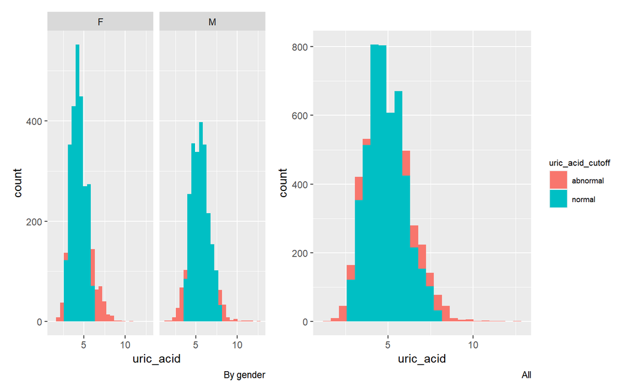

```r
uric_acid_gender_plot =
  new_blsa_clean %>%
  ggplot() +
  geom_histogram(aes(x = uric_acid, fill = uric_acid_cutoff), bins = 25) +
  facet_wrap(~gender) +
  theme(legend.position = "none") +
  labs(caption = "By gender") +
  scale_fill_discrete(breaks = c("abnormal", "normal"))

uric_acid_all_plot =
  new_blsa_clean %>%
  ggplot() +
  geom_histogram(aes(x = uric_acid, fill = uric_acid_cutoff), bins = 25) +
  theme(legend.text = element_text(size = 7),
        legend.title = element_text(size = 8)) +
  labs(caption = "All") +
  scale_fill_discrete(breaks = c("abnormal", "normal"))

uric_acid_fig = uric_acid_gender_plot + uric_acid_all_plot
uric_acid_fig
```

## Urine24 Cortisol, Free (ug/24hrs)

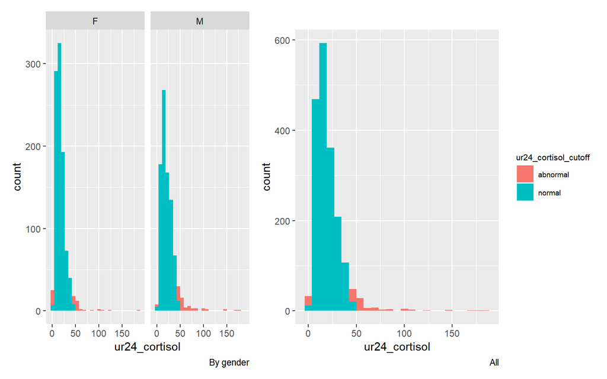

```r
ur24_cortisol_gender_plot =
  new_blsa_clean %>%
  ggplot() +
  geom_histogram(aes(x = ur24_cortisol, fill = ur24_cortisol_cutoff), bins = 25) +
  facet_wrap(~gender) +
  theme(legend.position = "none") +
  labs(caption = "By gender") +
  scale_fill_discrete(breaks = c("abnormal", "normal"))

ur24_cortisol_all_plot =
  new_blsa_clean %>%
  ggplot() +
  geom_histogram(aes(x = ur24_cortisol, fill = ur24_cortisol_cutoff), bins = 25) +
  theme(legend.text = element_text(size = 7),
        legend.title = element_text(size = 8)) +
  labs(caption = "All") +
  scale_fill_discrete(breaks = c("abnormal", "normal"))

ur24_cortisol_fig = ur24_cortisol_gender_plot + ur24_cortisol_all_plot
ur24_cortisol_fig
```

## VIT B12 (pg/mL)

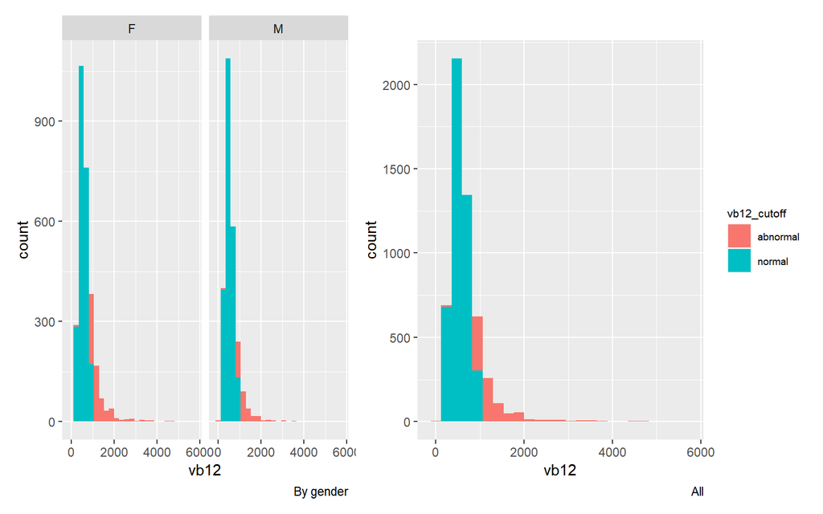

```r
vb12_gender_plot =
  new_blsa_clean %>%
  ggplot() +
  geom_histogram(aes(x = vb12, fill = vb12_cutoff), bins = 25) +
  facet_wrap(~gender) +
  theme(legend.position = "none") +
  labs(caption = "By gender") +
  scale_fill_discrete(breaks = c("abnormal", "normal"))

vb12_all_plot =
  new_blsa_clean %>%
  ggplot() +
  geom_histogram(aes(x = vb12, fill = vb12_cutoff), bins = 25) +
  theme(legend.text = element_text(size = 7),
        legend.title = element_text(size = 8)) +
  labs(caption = "All") +
  scale_fill_discrete(breaks = c("abnormal", "normal"))

vb12_fig = vb12_gender_plot + vb12_all_plot
vb12_fig
```

## Waist circumference (cm)

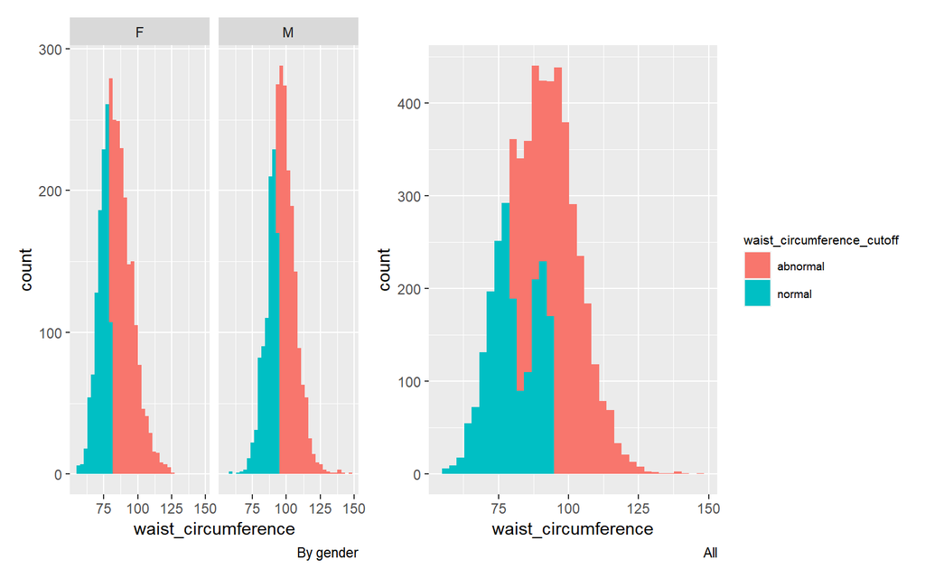

```r
waist_circumference_gender_plot =
  new_blsa_clean %>%
  ggplot() +
  geom_histogram(aes(x = waist_circumference, fill = waist_circumference_cutoff), bins = 35) +
  facet_wrap(~gender) +
  theme(legend.position = "none") +
  labs(caption = "By gender")


waist_circumference_all_plot =
  new_blsa_clean %>%
  ggplot() +
  geom_histogram(aes(x = waist_circumference, fill = waist_circumference_cutoff), bins = 35) +
  theme(legend.text = element_text(size = 7),
        legend.title = element_text(size = 8)) +
  labs(caption = "All")

waist_circumference_fig = waist_circumference_gender_plot + waist_circumference_all_plot
waist_circumference_fig
```

# Distributions of AL score, MRmean, and RMRmean:

## AL score distribution:

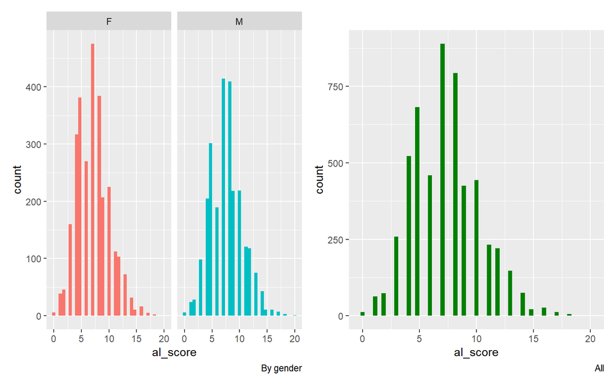

```r
al_score_gender_plot =
  new_blsa_clean %>%
  ggplot(., aes(x = al_score, fill = gender)) +
  geom_histogram(bins = 35) +
  facet_wrap(~gender) +
  theme(legend.position = "none") +
  labs(caption = "By gender")


al_score_all_plot =
  new_blsa_clean %>%
  ggplot() +
  geom_histogram(aes(x = al_score), bins = 55, fill = "#008000") +
  theme(legend.text = element_text(size = 7),
        legend.title = element_text(size = 8)) +
  labs(caption = "All")

al_score_fig = al_score_gender_plot + al_score_all_plot
al_score_fig
```

## MRmean distribution:

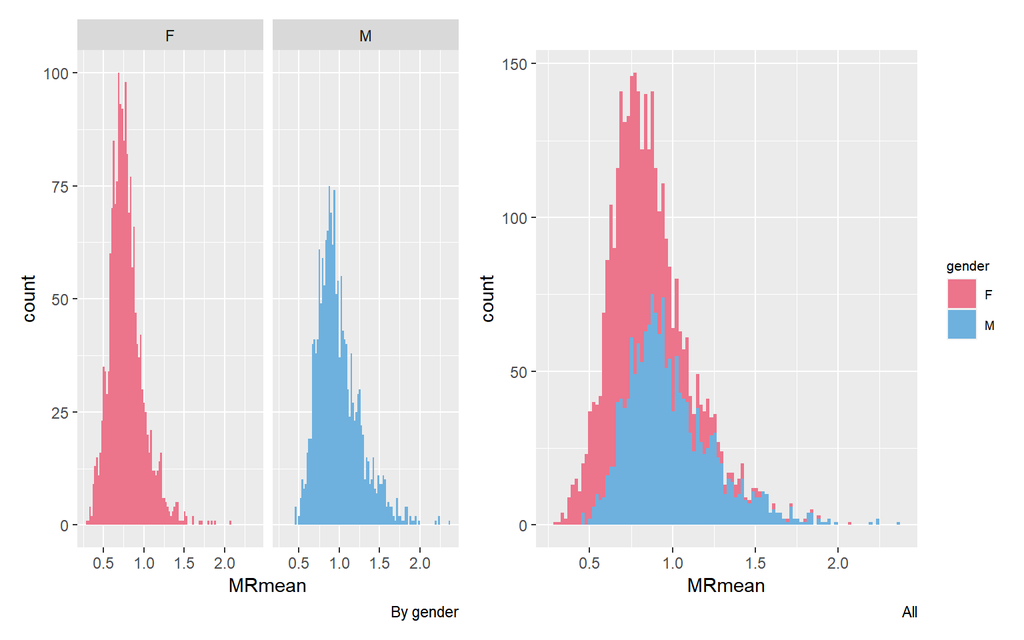

```r
MR_gender_plot =
  new_blsa_clean %>%
  ggplot() +
  geom_histogram(aes(x = MRmean, fill = gender), bins = 100) +
  facet_wrap(~gender) +
  theme(legend.position = "none") +
  labs(caption = "By gender") +
  scale_fill_manual(values = c("#EC748B", "#6EB1DE"))

MR_all_plot =
  new_blsa_clean %>%
  ggplot() +
  geom_histogram(aes(x = MRmean, fill = gender), bins = 100) +
  theme(legend.text = element_text(size = 7),
        legend.title = element_text(size = 8)) +
  labs(caption = "All") +
  scale_fill_manual(values = c("#EC748B", "#6EB1DE"))

MR_fig = MR_gender_plot + MR_all_plot
MR_fig
```

## RMR distribution

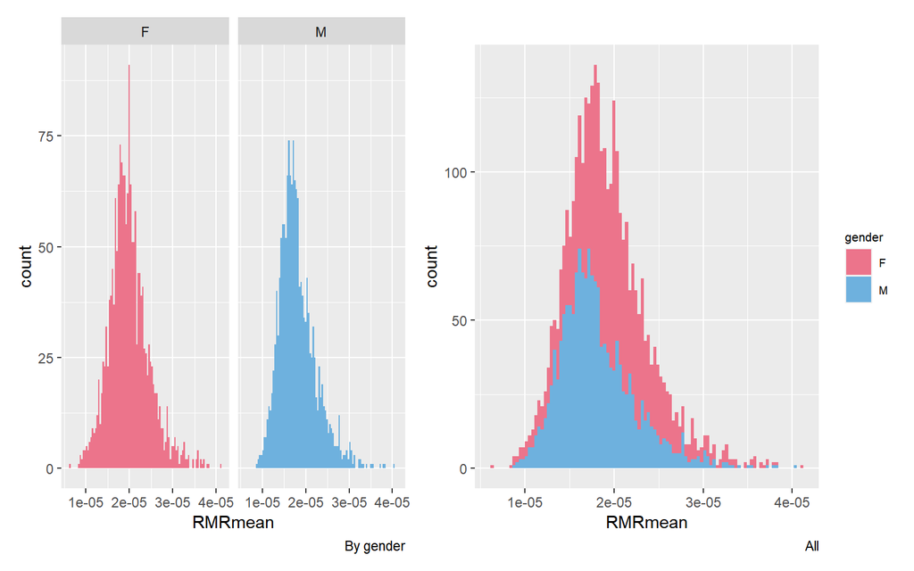

```r
RMR_gender_plot =
  new_blsa_clean %>%
  ggplot() +
  geom_histogram(aes(x = RMRmean, fill = gender), bins = 100) +
  facet_wrap(~gender) +
  theme(legend.position = "none") +
  labs(caption = "By gender") +
  scale_fill_manual(values = c("#EC748B", "#6EB1DE"))

RMR_all_plot =
  new_blsa_clean %>%
  ggplot() +
  geom_histogram(aes(x = RMRmean, fill = gender), bins = 100) +
  theme(legend.text = element_text(size = 7),
        legend.title = element_text(size = 8)) +
  labs(caption = "All") +
  scale_fill_manual(values = c("#EC748B", "#6EB1DE"))

RMR_fig = RMR_gender_plot + RMR_all_plot
RMR_fig
```

# Associations of AL score:

## Age vs. AL score:

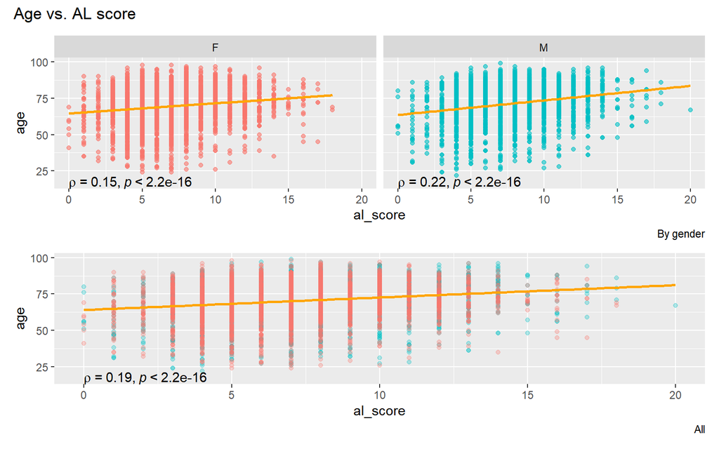

```r
prvage_gender_plot =
  new_blsa_clean %>%
  ggplot(., aes(x = al_score, y = age, color = gender)) +
  geom_point(alpha = 0.6) +
  geom_smooth(method = lm, se = F, color = "orange") +
  facet_wrap(~gender) +
  labs(caption = "By gender") +
  theme(legend.position = "none") +
  stat_cor(method = "pearson", label.x = 0, label.y = 17,
           cor.coef.name = "rho", color = "black")

prvage_all_plot =
  new_blsa_clean %>%
  ggplot(., aes(x = al_score, y = age, color = gender)) +
  geom_point(alpha = 0.3) +
  geom_smooth(method = lm, se = F, color = "orange") +
  labs(caption = "All") +
  theme(legend.position = "none") +
  stat_cor(method = "pearson", label.x = 0, label.y = 17,
           cor.coef.name = "rho", color = "black")


prvage_fig = prvage_gender_plot / prvage_all_plot + plot_annotation(title = 'Age vs. AL score')
prvage_fig
```

## MRmean vs. AL score:

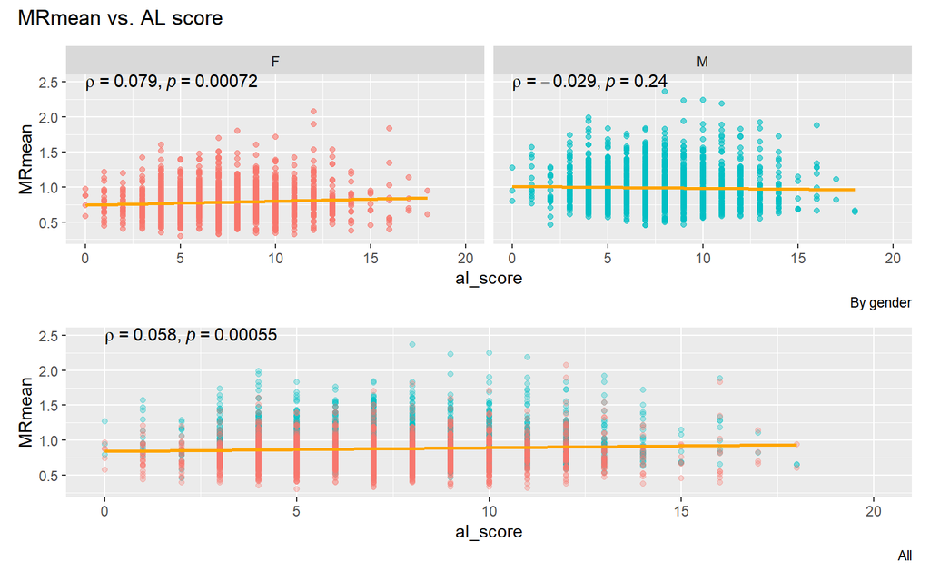

```r
prvmr_gender_plot =
  new_blsa_clean %>%
  ggplot(., aes(x = al_score, y = MRmean, color = gender)) +
  geom_point(alpha = 0.6) +
  geom_smooth(method = lm, se = F, color = "orange") +
  facet_wrap(~gender) +
  labs(caption = "By gender") +
  theme(legend.position = "none") +
  stat_cor(method = "pearson", label.x = 0, label.y = 2.5,
           cor.coef.name = "rho", color = "black")

prvmr_all_plot =
  new_blsa_clean %>%
  ggplot(., aes(x = al_score, y = MRmean, color = gender)) +
  geom_point(alpha = 0.3) +
  geom_smooth(method = lm, se = F, color = "orange") +
  labs(caption = "All") +
  theme(legend.position = "none") +
  stat_cor(method = "pearson", label.x = 0, label.y = 2.5,
           cor.coef.name = "rho", color = "black")


prvmr_fig = prvmr_gender_plot / prvmr_all_plot + plot_annotation(title = 'MRmean vs. AL score')
prvmr_fig
```

## RMRmean vs. AL score:

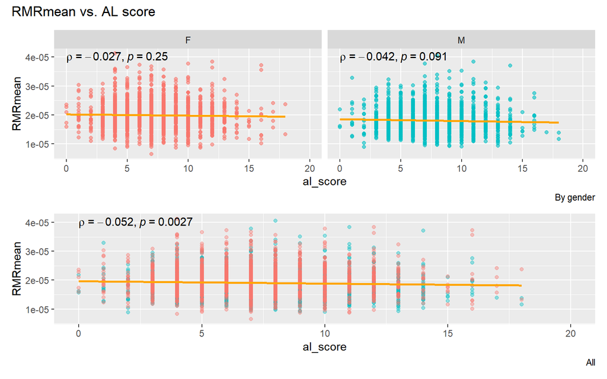

```r
prvrmr_gender_plot =
  new_blsa_clean %>%
  ggplot(., aes(x = al_score, y = RMRmean, color = gender)) +
  geom_point(alpha = 0.6) +
  geom_smooth(method = lm, se = F, color = "orange") +
  facet_wrap(~gender) +
  labs(caption = "By gender") +
  theme(legend.position = "none") +
  stat_cor(method = "pearson", label.x = 0, label.y = 4e-05,
           cor.coef.name = "rho", color = "black")

prvrmr_all_plot =
  new_blsa_clean %>%
  ggplot(., aes(x = al_score, y = RMRmean, color = gender)) +
  geom_point(alpha = 0.4) +
  geom_smooth(method = lm, se = F, color = "orange") +
  labs(caption = "All") +
  theme(legend.position = "none") +
  stat_cor(method = "pearson", label.x = 0, label.y = 4e-05,
           cor.coef.name = "rho", color = "black")


prvrmr_fig = prvrmr_gender_plot / prvrmr_all_plot + plot_annotation(title = 'RMRmean vs. AL score')
prvrmr_fig
```

# Generalized estimating equations (GEEs) without Covariate BMI:

## Data preparing for GEEs:

```r
# Data preparing for GEES:
new_blsa_clean.gee =
  new_blsa_clean %>%
  mutate(age2 = age^2)


new_blsa_clean_male.gee =
  new_blsa_clean.gee %>%
  filter(gender == "M")


new_blsa_clean_female.gee =
  new_blsa_clean.gee %>%
  filter(gender == "F")

new_blsa_clean.gee <- new_blsa_clean.gee[complete.cases(new_blsa_clean.gee[, c("MRmean", "RMRmean", "age", "bmi")]), ]
new_blsa_clean_male.gee <- new_blsa_clean_male.gee[complete.cases(new_blsa_clean_male.gee[, c("MRmean", "RMRmean", "age", "bmi")]), ]
new_blsa_clean_female.gee <- new_blsa_clean_female.gee[complete.cases(new_blsa_clean_female.gee[, c("MRmean", "RMRmean", "age", "bmi")]), ]
```

Since `geepack` package only works for complete data, so we drop observations with missing data for `new_blsa_clean`. There is three datasets are created for GEEs: `new_blsa_clean.gee`, `new_blsa_clean_male.gee` and `new_blsa_clean_female.gee`. The bar plots are shown as follows:

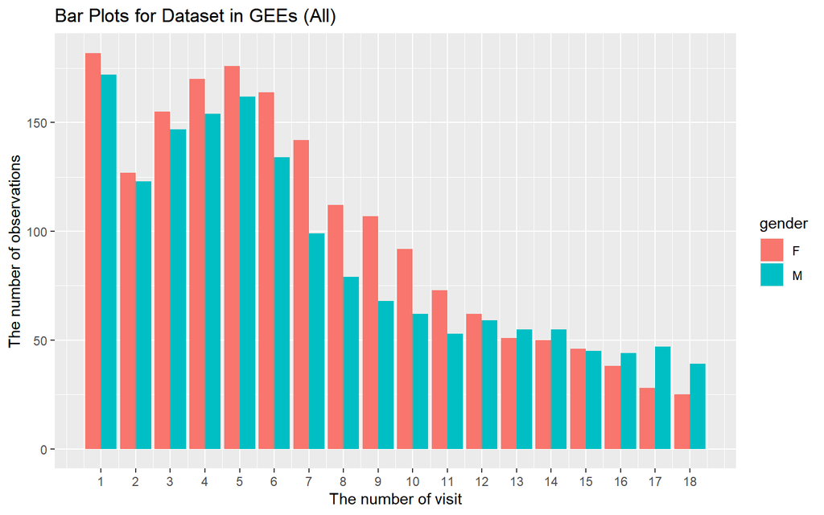

```r
new_blsa_clean.gee %>%
  select(gender, visit, bmi:AFG) %>%
  ggplot(aes(x = visit, fill = gender)) +
  geom_bar(position = "dodge") +
  labs(x = "The number of visit", y = "The number of observations") +
  scale_x_continuous(breaks = seq(1, 18, 1)) +
  ggtitle("Bar Plots for Dataset in GEEs (All)")
```

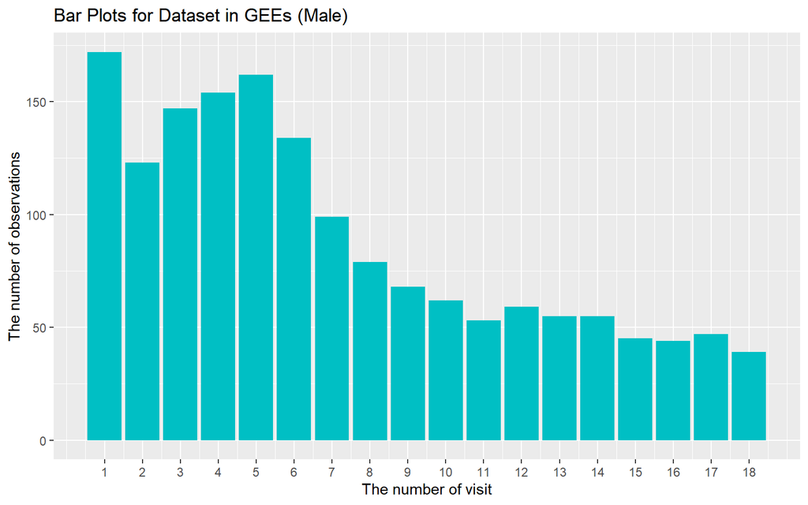

```r
new_blsa_clean_male.gee %>%
  select(gender, visit, bmi:AFG) %>%
  ggplot(aes(x = visit, fill = gender)) +
  geom_bar(position = "dodge") +
  labs(x = "The number of visit", y = "The number of observations") +
  scale_x_continuous(breaks = seq(1, 18, 1))  +
  theme(legend.position = "none") +
  ggtitle("Bar Plots for Dataset in GEEs (Male)") +
  scale_fill_manual(values = "#00BFC4")
```

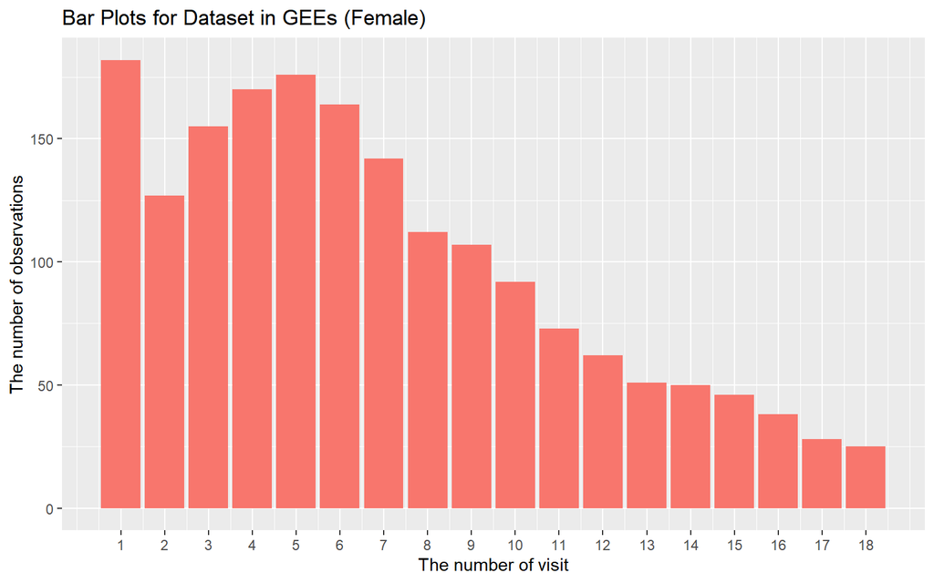

```r
new_blsa_clean_female.gee %>%
  select(gender, visit, bmi:AFG) %>%
  ggplot(aes(x = visit, fill = gender)) +
  geom_bar(position = "dodge") +
  labs(x = "The number of visit", y = "The number of observations") +
  scale_x_continuous(breaks = seq(1, 18, 1))  +
  theme(legend.position = "none") +
  ggtitle("Bar Plots for Dataset in GEEs (Female)")
```

## MRmean ~ AL (All) + age + age^2 + gender:

```r
mral.all =
       geeglm(scale(MRmean) ~ scale(al_score) + age + age2 + gender,
       data = new_blsa_clean.gee,
       family = gaussian(link = "identity"),
       id = id,
       corstr = "exchangeable")
tab_model(mral.all,
          show.reflvl = T,
          show.intercept = T,
          show.se = T,
          p.style = "numeric_stars")
```

scale(MRmean)

Predictors

Estimates

std. Error

CI

p

(Intercept)

-0.34

0.30

-0.94 – 0.25

0.258

age

0.03 ***

0.01

0.01 – 0.05

**0.001**

age2

-0.00 ***

0.00

-0.00 – -0.00

**<0.001**

genderM

0.88 ***

0.04

0.81 – 0.96

**<0.001**

scale(al_score)

0.05 **

0.02

0.02 – 0.09

**0.003**

N <sub>id</sub>

1281

Observations

3397

- p<0.05 ** p<0.01 *** p<0.001

## MRmean ~ AL (Male) + age + age^2:

```r
mral.male =
       geeglm(scale(MRmean) ~ scale(al_score) + age + age2,
       data = new_blsa_clean_male.gee,
       family = gaussian(link = "identity"),
       id = id,
       corstr = "exchangeable")
tab_model(mral.male,
          show.reflvl = T,
          show.intercept = T,
          show.se = T,
          p.style = "numeric_stars")
```

scale(MRmean)

Predictors

Estimates

std. Error

CI

p

(Intercept)

-0.33

0.41

-1.14 – 0.48

0.427

age

0.05 ***

0.01

0.03 – 0.08

**<0.001**

age2

-0.00 ***

0.00

-0.00 – -0.00

**<0.001**

scale(al_score)

0.04

0.03

-0.02 – 0.09

0.175

N <sub>id</sub>

587

Observations

1597

- p<0.05 ** p<0.01 *** p<0.001

## MRmean ~ AL (Female) + age + age^2:

```r
mral.female =
       geeglm(scale(MRmean) ~ scale(al_score) + age + age2,
       data = new_blsa_clean_female.gee,
       family = gaussian(link = "identity"),
       id = id,
       corstr = "exchangeable")
tab_model(mral.female,
          show.reflvl = T,
          show.intercept = T,
          show.se = T,
          p.style = "numeric_stars")
```

scale(MRmean)

Predictors

Estimates

std. Error

CI

p

(Intercept)

0.63

0.52

-0.38 – 1.65

0.221

age

0.01

0.02

-0.02 – 0.04

0.428

age2

-0.00 *

0.00

-0.00 – -0.00

**0.010**

scale(al_score)

0.09 **

0.03

0.04 – 0.15

**0.001**

N <sub>id</sub>

694

Observations

1800

- p<0.05 ** p<0.01 *** p<0.001

## RMRmean ~ AL (All) + age + age^2 + gender:

```r
rmral.all =
       geeglm(scale(RMRmean) ~ scale(al_score) + age + age2 + gender,
       data = new_blsa_clean.gee,
       family = gaussian(link = "identity"),
       id = id,
       corstr = "exchangeable")
tab_model(rmral.all,
          show.reflvl = T,
          show.intercept = T,
          show.se = T,
          p.style = "numeric_stars")
```

scale(RMRmean)

Predictors

Estimates

std. Error

CI

p

(Intercept)

0.32

0.32

-0.30 – 0.94

0.312

age

0.01

0.01

-0.01 – 0.03

0.253

age2

-0.00 *

0.00

-0.00 – -0.00

**0.017**

genderM

-0.38 ***

0.04

-0.46 – -0.30

**<0.001**

scale(al_score)

-0.02

0.02

-0.06 – 0.02

0.397

N <sub>id</sub>

1281

Observations

3397

- p<0.05 ** p<0.01 *** p<0.001

## RMRmean ~ AL (Male) + age + age^2:

```r
rmral.male =
       geeglm(scale(RMRmean) ~ scale(al_score) + age + age2,
       data = new_blsa_clean_male.gee,
       family = gaussian(link = "identity"),
       id = id,
       corstr = "exchangeable")
tab_model(rmral.male,
          show.reflvl = T,
          show.intercept = T,
          show.se = T,
          p.style = "numeric_stars")
```

scale(RMRmean)

Predictors

Estimates

std. Error

CI

p

(Intercept)

-0.51

0.45

-1.39 – 0.37

0.253

age

0.03 *

0.01

0.00 – 0.06

**0.021**

age2

-0.00 **

0.00

-0.00 – -0.00

**0.002**

scale(al_score)

-0.03

0.03

-0.09 – 0.03

0.327

N <sub>id</sub>

587

Observations

1597

- p<0.05 ** p<0.01 *** p<0.001

## RMRmean ~ AL (Female) + age + age^2:

```r
rmral.female =
       geeglm(scale(RMRmean) ~ scale(al_score) + age + age2,
       data = new_blsa_clean_female.gee,
       family = gaussian(link = "identity"),
       id = id,
       corstr = "exchangeable")
tab_model(rmral.female,
          show.reflvl = T,
          show.intercept = T,
          show.se = T,
          p.style = "numeric_stars")
```

scale(RMRmean)

Predictors

Estimates

std. Error

CI

p

(Intercept)

0.71

0.46

-0.19 – 1.60

0.123

age

-0.01

0.01

-0.03 – 0.02

0.639

age2

-0.00

0.00

-0.00 – 0.00

0.658

scale(al_score)

-0.01

0.03

-0.07 – 0.04

0.628

N <sub>id</sub>

694

Observations

1800

- p<0.05 ** p<0.01 *** p<0.001

# Generalized estimating equations (GEEs) with Covariate BMI:

## MRmean ~ AL (all) + age + age^2 + gender + BMI:

```r
mral_bmi.all =
       geeglm(scale(MRmean) ~ scale(al_score) + age + age2 + gender + bmi,
       data = new_blsa_clean.gee,
       family = gaussian(link = "identity"),
       id = id,
       corstr = "exchangeable")
tab_model(mral_bmi.all,
          show.reflvl = T,
          show.intercept = T,
          show.se = T,
          p.style = "numeric_stars")
```

scale(MRmean)

Predictors

Estimates

std. Error

CI

p

(Intercept)

-1.25 ***

0.29

-1.82 – -0.68

**<0.001**

age

0.01

0.01

-0.00 – 0.03

0.099

age2

-0.00 ***

0.00

-0.00 – -0.00

**<0.001**

bmi

0.05 ***

0.00

0.04 – 0.06

**<0.001**

genderM

0.86 ***

0.04

0.79 – 0.93

**<0.001**

scale(al_score)

-0.03

0.02

-0.06 – 0.01

0.119

N <sub>id</sub>

1281

Observations

3397

- p<0.05 ** p<0.01 *** p<0.001

## MRmean ~ AL (Male) + age + age^2 + BMI:

```r
mral_bmi.male =
       geeglm(scale(MRmean) ~ scale(al_score) + age + age2 + bmi,
       data = new_blsa_clean_male.gee,
       family = gaussian(link = "identity"),
       id = id,
       corstr = "exchangeable")
tab_model(mral_bmi.male,
          show.reflvl = T,
          show.intercept = T,
          show.se = T,
          p.style = "numeric_stars")
```

scale(MRmean)

Predictors

Estimates

std. Error

CI

p

(Intercept)

-1.58 ***

0.44

-2.45 – -0.71

**<0.001**

age

0.03 **

0.01

0.01 – 0.06

**0.008**

age2

-0.00 ***

0.00

-0.00 – -0.00

**<0.001**

bmi

0.06 ***

0.01

0.04 – 0.07

**<0.001**

scale(al_score)

-0.05

0.03

-0.10 – 0.01

0.090

N <sub>id</sub>

587

Observations

1597

- p<0.05 ** p<0.01 *** p<0.001

## MRmean ~ AL (Female) + age + age^2 + BMI:

```r
mral_bmi.female =
       geeglm(scale(MRmean) ~ scale(al_score) + age + age2 + bmi,
       data = new_blsa_clean_female.gee,
       family = gaussian(link = "identity"),
       id = id,
       corstr = "exchangeable")
tab_model(mral_bmi.female,
          show.reflvl = T,
          show.intercept = T,
          show.se = T,
          p.style = "numeric_stars")
```

scale(MRmean)

Predictors

Estimates

std. Error

CI

p

(Intercept)

-0.25

0.48

-1.19 – 0.68

0.599

age

-0.01

0.01

-0.04 – 0.02

0.619

age2

-0.00

0.00

-0.00 – 0.00

0.253

bmi

0.05 ***

0.01

0.04 – 0.06

**<0.001**

scale(al_score)

-0.01

0.03

-0.07 – 0.04

0.685

N <sub>id</sub>

694

Observations

1800

- p<0.05 ** p<0.01 *** p<0.001

## RMRmean ~ AL (All) + age + age^2 + gender + BMI:

```r
rmral_bmi.all =
       geeglm(scale(RMRmean) ~ scale(al_score) + age + age2 + gender + bmi,
       data = new_blsa_clean.gee,
       family = gaussian(link = "identity"),
       id = id,
       corstr = "exchangeable")
tab_model(rmral_bmi.all,
          show.reflvl = T,
          show.intercept = T,
          show.se = T,
          p.style = "numeric_stars")
```

scale(RMRmean)

Predictors

Estimates

std. Error

CI

p

(Intercept)

0.26

0.33

-0.39 – 0.90

0.436

age

0.01

0.01

-0.01 – 0.03

0.310

age2

-0.00 *

0.00

-0.00 – -0.00

**0.028**

bmi

0.00

0.00

-0.01 – 0.01

0.485

genderM

-0.38 ***

0.04

-0.46 – -0.30

**<0.001**

scale(al_score)

-0.02

0.02

-0.06 – 0.02

0.275

N <sub>id</sub>

1281

Observations

3397

- p<0.05 ** p<0.01 *** p<0.001

## RMRmean ~ AL (Male) + age + age^2 + BMI:

```r
rmral_bmi.male =
       geeglm(scale(RMRmean) ~ scale(al_score) + age + age2 + bmi,
       data = new_blsa_clean_male.gee,
       family = gaussian(link = "identity"),
       id = id,
       corstr = "exchangeable")
tab_model(rmral_bmi.male,
          show.reflvl = T,
          show.intercept = T,
          show.se = T,
          p.style = "numeric_stars")
```

scale(RMRmean)

Predictors

Estimates

std. Error

CI

p

(Intercept)

-0.85

0.48

-1.78 – 0.08

0.074

age

0.03

0.01

-0.00 – 0.06

0.051

age2

-0.00 **

0.00

-0.00 – -0.00

**0.008**

bmi

0.02

0.01

-0.00 – 0.03

0.058

scale(al_score)

-0.05

0.03

-0.11 – 0.01

0.090

N <sub>id</sub>

587

Observations

1597

- p<0.05 ** p<0.01 *** p<0.001

## RMRmean ~ AL (Female) + age + age^2 + BMI:

```r
rmral_bmi.female = geeglm(scale(RMRmean) ~ scale(al_score) + age + age2 + bmi,
       data = new_blsa_clean_female.gee,
       family = gaussian(link = "identity"),
       id = id,
       corstr = "exchangeable")

tab_model(rmral_bmi.female,
          show.reflvl = T,
          show.intercept = T,
          show.se = T,
          p.style = "numeric_stars")
```

scale(RMRmean)

Predictors

Estimates

std. Error

CI

p

(Intercept)

0.74

0.47

-0.18 – 1.66

0.117

age

-0.01

0.01

-0.03 – 0.02

0.673

age2

-0.00

0.00

-0.00 – 0.00

0.629

bmi

-0.00

0.01

-0.01 – 0.01

0.792

scale(al_score)

-0.01

0.03

-0.07 – 0.05

0.747

N <sub>id</sub>

694

Observations

1800

- p<0.05 ** p<0.01 *** p<0.001